## Evaluating classification models

Classification in text analysis is a supervised machine learning technique to predict the predefined category to which a document belongs. In this dataset, the predefined category is sentiment polarity (positive or negative) of hotel reviews. To execute classification, two subsets of data are required: training data to train the classifier and test data to validate it. Here, I have used the Naive Bayes model for classification. Because of the data being large, I wasn’t able to compare the Naive Bayes model with Linear Support Vector Machines model. The Naive Bayes model is computationally more efficient than SVMs model. I have evaluated the model using confusion matrix and cross validation.

This dataset consists of 878561 reviews of 4333 hotels from Tripadvisor website.

First, I will load required libraries. I need quanteda and quanteda.textmodels for creating document feature matrix and evaluating models.

```r
library(tidyverse)
```

```r
library(ggplot2)
require(lattice)
library(quanteda)
library(quanteda.textmodels)
library(quanteda.textplots)
library(quanteda.textstats)
library(readtext)
library(jsonlite)
```

I will load both reviews and offerings datasets. Reviews dataset includes reviews as well as ratings by customers. Offerings include all the information about the hotel including the hotel’s name, the city in which the hotel is located, its class, and a hotel id.

```r
tripadvisor_reviews = read.csv(file = "reviews.csv", header = TRUE)
```

```r
dim(tripadvisor_reviews)
```

```
## [1] 878561     10
```

```r
tripadvisor_offerings = read.csv(file = "offerings.csv", header = TRUE)
```

```r
hotels_id <- unique(tripadvisor_offerings$id)
```

```r
length(hotels_id)
```

```
## [1] 4333
```

There are reviews of 4333 hotels in this dataset.

```r
#Dictionaries in the ratings column use single quotes instead of double quotes which is not a valid json. First, I replace single quotes with double quotes in the 'ratings' column.

tripadvisor_reviews$ratings <- gsub("'", '"', tripadvisor_reviews$ratings)

#Then I convert to JSON format.

tripadvisor_reviews$ratings <- lapply(tripadvisor_reviews$ratings, fromJSON)
```

```r
tripadvisor_split_columns <- tripadvisor_reviews %>%
  unnest_wider(ratings)
tripadvisor_split_columns
```

```
## # A tibble: 878,561 × 18
##    service cleanliness overall value location sleep_quality rooms
##      <dbl>       <dbl>   <dbl> <dbl>    <dbl>         <dbl> <dbl>
##  1       5           5       5     5        5             5     5
##  2       5           5       5     5        5             5     5
##  3       4           5       4     4        5             4     4
##  4       5           5       4     5        5             5     5
##  5       4           5       4     3        5             5     5
##  6       5           5       5     4        5             4     5
##  7       5           5       5     4        4            NA     5
##  8       5           5       5     4        5             5     5
##  9       5           5       5     4        5             5     5
## 10       4           5       4     4        5             5     4
## # ℹ 878,551 more rows
## # ℹ 11 more variables: check_in_front_desk <dbl>,
## #   `business_service_(e_g_internet_access)` <dbl>, title <chr>, text <chr>,
## #   author <chr>, date_stayed <chr>, offering_id <int>,
## #   num_helpful_votes <int>, date <chr>, id <int>, via_mobile <chr>
```

Similarly, in the offerings dataset, there is a column “address” which includes the region, street address, postal code and locality. I will split this column into 4 categories.

```r
tripadvisor_offerings$address <- gsub("'", '"', tripadvisor_offerings$address)
```

```r
tripadvisor_offerings$address <- gsub('O"', 'O', tripadvisor_offerings$address)

tripadvisor_offerings$address <- gsub('Mary"s', 'Marys', tripadvisor_offerings$address)

tripadvisor_offerings$address <- gsub('"630 "F" Street"', '"630 F Street"', tripadvisor_offerings$address)

tripadvisor_offerings$address <- gsub('"4143 Governor"s Row"', '"4143 Governors Row"', tripadvisor_offerings$address)

tripadvisor_offerings$address <- gsub('"CO', '"CO"', tripadvisor_offerings$address)

tripadvisor_offerings$address <- gsub('"480 L"Enfant Plaza"', '"480 LEnfant Plaza"', tripadvisor_offerings$address)
```

```r
tripadvisor_offerings$address <- lapply(tripadvisor_offerings$address, fromJSON)
```

```r
tripadvisor_offerings_split <- tripadvisor_offerings %>%
  unnest_wider(address)
tripadvisor_offerings_split
```

```
## # A tibble: 4,333 × 12
##    hotel_class region_id url               phone details region `street-address`
##          <dbl>     <int> <chr>             <lgl> <lgl>   <chr>  <chr>
##  1         4       60763 http://www.tripa… NA    NA      NY     147 West 43rd S…
##  2         5       32655 http://www.tripa… NA    NA      CA     300 S Doheny Dr
##  3         3.5     60763 http://www.tripa… NA    NA      NY     790 Eighth Aven…
##  4         4       60763 http://www.tripa… NA    NA      NY     152 West 51st S…
##  5         4       60763 http://www.tripa… NA    NA      NY     130 West 46th S…
##  6         4.5     60763 http://www.tripa… NA    NA      NY     45 West 44th St…
##  7        NA       60763 http://www.tripa… NA    NA      NY     1170 Broadway &…
##  8         3.5     60763 http://www.tripa… NA    NA      NY     340 West 40th S…
##  9         4.5     60763 http://www.tripa… NA    NA      NY     781 Fifth Avenue
## 10         4       60763 http://www.tripa… NA    NA      NY     150 East 50th S…
## # ℹ 4,323 more rows
## # ℹ 5 more variables: `postal-code` <chr>, locality <chr>, type <chr>,
## #   id <int>, name <chr>
```

I will merge the 2 datasets using id, but before merging, I need to change the name of column “id” in offerings dataset to “offering_id”:

```r
tripadvisor_offerings_split <- tripadvisor_offerings_split %>%
  rename(offering_id = id)
```

Merging two datasets

```r
tripadvisor <- merge(tripadvisor_split_columns,tripadvisor_offerings_split, by=c("offering_id")
)
```

I’ll have a look at reviews with the overall score of 3.

```r
tripadvisor_overall_3 <- tripadvisor %>%
  filter(overall == 3) %>%
  select(text, overall, title)
```

I will create a column “polarity” which divides data to negative and positive reviews based on customer ratings.

```r
tripadvisor <- tripadvisor %>%
  mutate(
    polarity = ifelse(
      overall >= 4
      |service >= 4
      |cleanliness >= 4
      |value >= 4
      |location >= 4
      |sleep_quality >= 4
      |rooms >= 4 , "positive", "negative"
    )
  )

unique(tripadvisor$polarity)
```

```
## [1] NA         "positive" "negative"
```

Hotels are located in these cities:

```r
unique(tripadvisor$locality)
```

```
##  [1] "Seattle"       "San Antonio"   "Houston"       "Fort Worth"
##  [5] "El Paso"       "Dallas"        "Phoenix"       "Austin"
##  [9] "Memphis"       "San Francisco" "Philadelphia"  "Washington DC"
## [13] "Columbus"      "New York City" "Los Angeles"   "San Diego"
## [17] "Boston"        "Baltimore"     "Indianapolis"  "Chicago"
## [21] "Denver"        "San Jose"      "Jacksonville"  "Detroit"
## [25] "Charlotte"
```

There are 25 cities in the data. I have randomly selected 3 cities because of the data set being so large.

```r
tripadvisor <- tripadvisor %>% filter(locality == "San Francisco" | locality == "Washington DC" | locality == "New York City")
```

```r
dim(tripadvisor)
```

```
## [1] 410308     30
```

Now, we have a column with negative and positive reviews based on customer ratings. Let’s have a look how many positive and how many negative reviews there are.

```r
table(tripadvisor$polarity)
```

```
##
## negative positive
##     5644   373943
```

```r
tripadvisor %>% count(polarity)
```

```
##   polarity      n
## 1 negative   5644
## 2 positive 373943
## 3     <NA>  30721
```

I will only keep those reviews that have ratings by customers:

```r
tripadvisor <- tripadvisor %>%
  filter(polarity == "positive" | polarity == "negative")

tripadvisor %>% count(polarity)
```

```
##   polarity      n
## 1 negative   5644
## 2 positive 373943
```

```r
tripadvisor <- tripadvisor %>%
  group_by(polarity) %>%
  mutate(
    set = ifelse(row_number() <= n()/2, "train","test")
    )
```

```r
table(tripadvisor$polarity, tripadvisor$set)
```

```
##
##              test  train
##   negative   2822   2822
##   positive 186972 186971
```

I need to create a corpus from a data frame:

```r
corp_tripadvisor <- corpus(tripadvisor, text_field = "text")
```

I’ll explore the corpus.

```r
head(docvars(corp_tripadvisor))
```

```
##   offering_id service cleanliness overall value location sleep_quality rooms
## 1       74059      NA          NA       5    NA       NA            NA    NA
## 2       74059       4           4       4     3        5             4     4
## 3       74059       3           5       3     1       NA             1    NA
## 4       74059       4           4       4     4        5             5     3
## 5       74059       1           3       1     1        2             1     3
## 6       74059       5           4       3     3        5            NA     3
##   check_in_front_desk business_service_(e_g_internet_access)
## 1                  NA                                     NA
## 2                  NA                                     NA
## 3                  NA                                     NA
## 4                  NA                                     NA
## 5                  NA                                     NA
## 6                   5                                      4
##                                                                                title
```

[output cut: 48 more lines]

Summary() function shows the number of types, tokens and sentences in each review.

```r
head(summary(corp_tripadvisor), 20)
```

```
##      Text Types Tokens Sentences offering_id service cleanliness overall value
## 1   text1    91    145         8       74059      NA          NA       5    NA
## 2   text2   251    447        23       74059       4           4       4     3
## 3   text3   145    241        13       74059       3           5       3     1
## 4   text4   128    220         9       74059       4           4       4     4
## 5   text5   158    251        15       74059       1           3       1     1
## 6   text6   112    186        12       74059       5           4       3     3
## 7   text7    46     60         5       74059       4           5       4     3
## 8   text8   154    234        13       74059      NA          NA       5    NA
## 9   text9    84    122        17       74059       3           4       3     2
## 10 text10   159    252        11       74059       3           3       3     3
## 11 text11   174    319        14       74059       3           5       2     2
## 12 text12   172    308        11       74059       5           5       4     4
## 13 text13    30     34         3       74059       5           5       5     4
## 14 text14   143    204        13       74059       4           4       4     3
```

[output cut: 195 more lines]

I’ll have a look at the first review.

```r
corp_tripadvisor[1] %>%
  cat()
```

```
## We stayed here for 3 weeks in a suite while my husband had a transplant at UCSF. This is just minutes from UCSF. This was the most peaceful and relaxing place to get away from it all. The staff was extremely helpful and very nice. They called cabs for me and there was always someone on staff. I n…
```

I will tokenise data and create a document feature matrix.

```r
tripadvisor_toks <- tokens(corp_tripadvisor, remove_punct = TRUE, remove_symbols = TRUE) %>%
  tokens_remove(stopwords("en")) %>%
  tokens_tolower()

tripadvisor_toks
```

```
## Tokens consisting of 379,587 documents and 30 docvars.
## text1 :
##  [1] "stayed"     "3"          "weeks"      "suite"      "husband"
##  [6] "transplant" "ucsf"       "just"       "minutes"    "ucsf"
## [11] "peaceful"   "relaxing"
## [ ... and 46 more ]
##
## text2 :
##  [1] "others"     "said"       "hotel"      "want"       "get"
##  [6] "away"       "generic"    "chains"     "want"       "standard"
## [11] "tourist"    "experience"
## [ ... and 196 more ]
##
## text3 :
##  [1] "stayed"     "6"          "days"       "whilst"     "travelling"
##  [6] "states"     "cupola"     "queen"      "room"       "provided"
## [11] "lovely"     "view"
## [ ... and 103 more ]
##
## text4 :
##  [1] "rv"         "vacation"   "california" "trouble"    "vehicle"
##  [6] "aaa"        "towed"      "garage"     "couple"     "blocks"
## [11] "stanyan"    "park"
## [ ... and 76 more ]
##
## text5 :
##  [1] "took"        "family"      "vacation"    "san"         "francisco"
##  [6] "august"      "displeasure" "choosing"    "stanyan"     "hotel"
## [11] "ordered"     "wetsuit"
## [ ... and 110 more ]
##
## text6 :
##  [1] "surprised" "see"       "negative"  "reviews"   "stanyan"   "park"
##  [7] "room"      "away"      "street"    "selected"  "room"      "website"
## [ ... and 64 more ]
##
## [ reached max_ndoc ... 379,581 more documents ]
```

I will create a document feature matrix.

```r
tripadvisor_dfmat <- tripadvisor_toks %>%
  dfm()
```

I split the data into positive and negative sentiment.

```r
dfmat_positive <- dfm_subset(tripadvisor_dfmat, polarity == "positive")

dfmat_negative <- dfm_subset(tripadvisor_dfmat, polarity == "negative")
```

I’ll have a look at the top features in the negative and positive subsets using topfeatures() function.

```r
print(topfeatures(dfmat_positive))
```

```
##    hotel     room    great    staff     stay location    rooms     good
##   661895   496057   236333   211209   208945   189083   166777   161120
##      one   stayed
##   140449   136738
```

```r
print(topfeatures(dfmat_negative))
```

```
## hotel  room  stay   one night rooms    us   get staff    la
## 11320 10262  3444  3146  2887  2873  2557  2415  2321  2266
```

I can also use textstat_frequency() function to view the top features by sentiment.

```r
textstat_frequency(tripadvisor_dfmat, n = 15, groups = polarity)
```

```
##     feature frequency rank docfreq    group
## 1     hotel     11320    1    4182 negative
## 2      room     10262    2    3552 negative
## 3      stay      3444    3    2285 negative
## 4       one      3146    4    1936 negative
## 5     night      2887    5    1811 negative
## 6     rooms      2873    6    1898 negative
## 7        us      2557    7    1263 negative
## 8       get      2415    8    1616 negative
## 9     staff      2321    9    1632 negative
## 10       la      2266   10     591 negative
## 11     desk      2231   11    1419 negative
## 12     just      2106   12    1403 negative
## 13       de      2093   13     405 negative
## 14      bed      2085   14    1305 negative
```

[output cut: 16 more lines]

### Evaluating classification models

I need to separate the training and test sets by subsetting the document feature matrix into two separate training and test matrices. I set the minimum term frequency to 10 to eliminate less frequently occuring terms.

```r
dfmat_train <- dfm_subset(tripadvisor_dfmat, set == "train") %>%
  dfm_trim(min_termfreq = 10)
```

```r
dfmat_test <- dfm_subset(tripadvisor_dfmat, set == "test") %>%
  dfm_trim(min_termfreq = 10)
```

Training the Naive Bayes classifier

First, I indicate the data which I want to train. I indicate y as outcome of interest, in this case polarity.

```r
tripadvisor_nb <- textmodel_nb(dfmat_train, y = dfmat_train$polarity)
```

Now that I have trained the classifier, I can use it to predict polarity in the test data.

```r
tripadvisor_nb_test <- predict(tripadvisor_nb, newdata = dfmat_test, force = TRUE)
```

Force = True is our way of telling the function that if it encounters features that were not found in the training dataset, then these should be dropped.

#### Model Evaluation

I need to know whether the model can issue reliable and accurate predictions. To assess the performance of the model, these measures are used: 1. Accuracy 2. Confusion Matrix 3. Precision and Recall

##### Confusion matrix

Confusion matrix looks at categories and determines which of these categories the model has successfully or unsuccessfully classified.

```r
confmat_nb <- table(tripadvisor_nb_test, dfmat_test$polarity)[2:1, 2:1]

confmat_nb
```

```
##
## tripadvisor_nb_test positive negative
##            positive   168384      739
##            negative    18588     2083
```

##### Accuracy

Accuracy determines how often the model is correct in predicting into which category a document falls. (true positives + true negatives) / ( all predictions)

I use the diag() function which will extract the diagonal of a matrix: the true positives and true negatives

```r
print(sum(diag(confmat_nb)) / sum(confmat_nb))
```

```
## [1] 0.8981685
```

##### Precision

In this dataset, where the predicted classes are imbalanced, the precision and recall are more helpful and show how the model has performed. Precision measures what proportion of predicted positive reviews are actually positive. true positives / (true positives + false positives)

```r
prec <- print(confmat_nb[1, 1] / sum(confmat_nb[1, ]))
```

```
## [1] 0.9956304
```

##### Recall

Recall measures what proportion of all positive cases are correctly predicted true positives / (true positives + false negatives)

```r
rec <- print(confmat_nb[1, 1] / sum(confmat_nb[, 1]))
```

```
## [1] 0.900584
```

##### F1 Score

We combine precision and recall into a single quantity called F1 score: 2 * (Recall * Precision) / (Recall + Precision)

```r
f1 <- 2 * (rec * prec) / (rec + prec)
f1
```

```
## [1] 0.9457252
```

##### Cross validation

Cross validation is a process of evaluating the model that relies on splitting the data and evaluating it segment by segment. Cross validation is used to avoid overfitting a model.

```r
set.seed(50)
tripadvisor_dfmat$split <- as.integer(cut(sample(seq_len(ndoc(tripadvisor_dfmat))), breaks = 5))
```

```r
table(tripadvisor_dfmat$split)
```

```
##
##     1     2     3     4     5
## 75918 75917 75917 75917 75918
```

```r
#Distribution of sentiment
with(docvars(tripadvisor_dfmat), table(polarity, split))
```

```
##           split
## polarity       1     2     3     4     5
##   negative  1141  1134  1144  1089  1136
##   positive 74777 74783 74773 74828 74782
```

```r
acc <- numeric()
```

```r
for (i in seq_len(5)) {

    dfmat_train2 <- tripadvisor_dfmat %>%
        dfm_subset(split != i) %>%
        dfm_trim(min_termfreq = 5)

    dfmat_test2 <- dfm_subset(tripadvisor_dfmat, split == i)

    tmod <- textmodel_nb(dfmat_train, y = dfmat_train$polarity)

    pred <- suppressWarnings(predict(tmod, newdata = dfmat_test, force = TRUE))

    confmat <- table(pred, dfmat_test$polarity)

    acc <- c(acc, sum(diag(confmat)) / sum(confmat))
}
```

```r
print(acc)
```

```
## [1] 0.8981685 0.8981685 0.8981685 0.8981685 0.8981685
```

```r
print(mean(acc))
```

```
## [1] 0.8981685
```

Visualizing the model

First, I create a dataframe object with desired variables from a test set.

```r
prediction_df <- data.frame(id = docnames(dfmat_test),
                      Prediction = tripadvisor_nb_test,
                      Rating = dfmat_test$overall)

head(prediction_df)
```

```
##                    id Prediction Rating
## text189686 text189686   positive      2
## text189687 text189687   positive      4
## text189688 text189688   positive      4
## text189689 text189689   positive      4
## text189690 text189690   positive      5
## text189691 text189691   positive      5
```

Now, I visualise prediction vs overall rating to observe how the classifier did in predicting polarity.

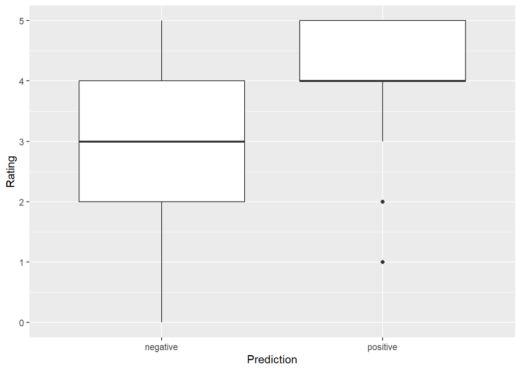

```r
ggplot(prediction_df, aes(x = Prediction, y = Rating)) +
  geom_boxplot()
```